# **Menstrual Health & Sexual Education In India**

Group 2: Kriti Vajjhula, Franchezca Layog, Ian Chandramouli, & Harmeet Singh

March 2021

## **Problem Domain Description**

Millions of women in India face great challenges to managing their menstrual health and practicing menstrual hygiene. This is due to a number of enabling factors present in the country’s distribution system for products, income level, and social stigma. One of the largest factors is the lack of education and awareness to young women in the process of menstruation and its physiological basis pre-menarche (before a young girl’s first menstrual cycle). Another key issue is the availability of products to all income levels. The pricing of commercial products are expensive as well as inaccessible to women in rural areas, who account for a significant portion of the country’s population. Sanitation routines, attitudes, and most importantly, facilities, are also very underdeveloped across the country and limit access to functioning toilets and disposal solutions. This harms working women as well as school going young women, greatly increasing the gender income gap in income as well as academia.

Our group is interested in delving into the sociocultural root of this problem and finding correlations, insights, and potential solutions for dismantling these enabling factors. We will attempt to focus on the cause of these enabling factors and finding connections in data between socioeconomic backgrounds, income levels, religion, caste, etc.

The first existing project we found is a country landscape analysis of menstrual health in India. The report seeks to understand the current state of womens’ health in India and includes research from interviews from adolescent girls from rural and urban areas.

Source: [Menstrual Health in India - Country Landscape Analysis](https://www.susana.org/en/knowledge-hub/resources-and-publications/library/details/2581)

The second existing project we examined studies the effect of a community-based health education intervention on change in behavior, routines, and awareness in the menstrual hygiene of rural adolescent girls.

Source: [The Effect of Community-Based Health Education Intervention on Management of Menstrual Hygiene among Rural Indian Adolescent Girls](https://www.longwoods.com/content/19303/world-health-population/the-effect-of-community-based-health-education-intervention-on-management-of-menstrual-hygiene-among)

## **Data Description**

### Percentage of Women Complication During Pregnancy Data Set

Source: [Percentage of Women Complication During Pregnancy](https://data.gov.in/resources/percentage-women-who-had-any-pregnancy-complication-any-delivery-complication-any-post)

This data set describes the percentage of women who had pregnancy complications according to different reasons such as menstrual related problems or delivery complications. The data was obtained by the Ministry of Health and Family Welfare of India. The data was collected via a nationwide survey in which Women answered a variety of questions. This data would hopefully answer the question as to which policies are effective in women’s menstrual healthcare. This dataset provides information about individual districts which can be used jointly with another dataset to answer our questions.

The data set will look like this:

| States | Districts | preg_comp | any_delivery_comp | any_post_delivery_comp | vag_discharge_comp | menstrual_related_comp |
| --- | --- | --- | --- | --- | --- | --- |
| Andaman and Nicobar Islands | Total | 46.2 | 39.1 | 21.1 | 6.5 | 11.7 |
| Andaman and Nicobar Islands | North & Middle Andamans | 29.1 | 20.1 | 10.7 | 4.4 | 3.5 |
| Andaman and Nicobar Islands | South Andaman | 57.0 | 48.8 | 23.6 | 10.6 | 19.1 |
| Andaman and Nicobar Islands | Nicobars | 35.3 | 34.5 | 19.3 | 2.0 | 5.1 |
| Andhra Pradesh | Total | 34.9 | 19.9 | 15.8 | 6.1 | 12.4 |
| Andhra Pradesh | Srikakulam | 24.6 | 11.7 | 7.9 | 10.5 | 19.8 |

*The above table is a sample of the data set preg_comp_df.*

The column names for this data set:  
- preg_comp = % Of Women with Any Pregnancy Complications  
- any_delivery_comp = % of Woman with Delivery Complications  
- any_post_delivery_comp = % of Women with Post-Delivery Complications  
- vag_discharge_comp = % of Women with Problems with Vaginal Discharge in Last 3 Months  
- menstrual_related_comp = % of Women with Menstrual Related Problems in Last 3 Months

#### Summary Statistics (preg_comp_df)

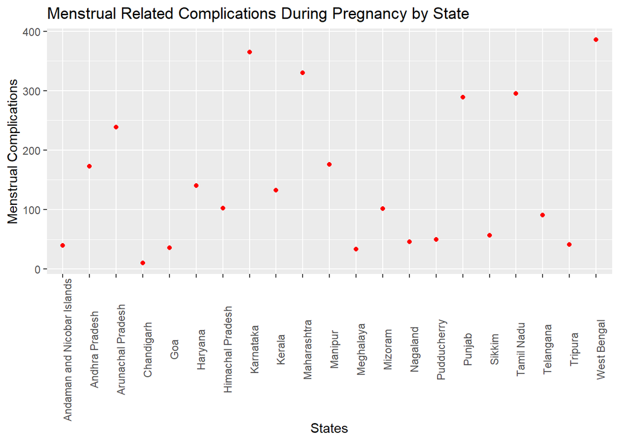

*The above plot describes the distribution of menstrual related complications during pregnancy cases across various states from the pre_comp_df data frame.*

#### *Percent of Women with Menstrual Complications*

The mean percentage of women reporting menstrual complications was 12.1028814.

These percentages ranged from 1.3% to 30.1%.

#### *Percent of Women with Pregnancy Complications*

The mean percentage of women reporting pregnancy complications was 37.6321469

These percentages ranged form 0% to 76.3%.

#### *Percentage of Women with Delivery Complications*

The mean percentage of women reporting delivery complications was 28.0580791%.

These percentages ranged from 0% to 81.5%.

#### *Percentage of Women with Vaginal Discharge Complications*

The mean percentage of women reporting vaginal discharge complications was 14.7734463%.

These percentages ranged from 0.6% to 61.5%.

#### *Percentage of Women with Post-Delivery Complications*

The mean percentage of women reporting post-delivery complications was 24.0585593%.

These percentages range from 0% to 91.8%.

#### Outliers

A notable outlier is West Bengal. This particular value is notable due to the fact that it indicates an unusually large amount of menstrual complications in relation to the rest of the data set. This can be attributable to the fact that West Bengal is one of the most populous states in the country.

### Menstrual Hygiene Scheme Budget 2016-2020 Data Set

Source: [Menstrual Hygiene Scheme Budget](https://data.gov.in/resources/stateut-wise-menstrual-hygiene-scheme-budget-approved-under-nhm-2016-17-2019-20-ministry)

The data was released by Rajya Sabha (Council of States), the upper house of the Indian Parliament. The government is logically the entity responsible for proposing the budget, and the data was therefore effectively generated by them. It was released under the National Data Sharing and Accessibility Policy. This will help us identify the financial disparities in government menstrual health support programs by state, which can provide insight as to how attitudes toward and the overall state of female menstrual health differ by state and region.

The data set will look like this:

| state_no | States | 2016-17 | 2017-18 | 2018-19 | 2019-20 |
| --- | --- | --- | --- | --- | --- |
| 1 | Andhra Pradesh | 202.53 | 404.05 | 407.81 | 0.00 |
| 2 | Assam | 374.47 | 390.70 | 254.43 | 288.62 |
| 3 | Bihar | 125.16 | 183.45 | 0.00 | 957.60 |
| 4 | Chhattisgarh | 0.00 | 0.00 | 99.75 | 0.00 |
| 5 | Delhi | 0.00 | 0.00 | 82.08 | 72.96 |
| 6 | Gujarat | 134.59 | 358.01 | 0.00 | 0.00 |

*The above table is a sample of the data set menstual_budget_df*

The column names for this data set:  
- state_no = State No. in Alphabetical Order  
- 2016-17 Budget  
- 2017-18 Budget  
- 2018-19 Budget  
- 2019-20 Budget

#### Summary Statistics (total_budgets_df)

[figure not shown]

#### *2016-2017*

The average spending for the years of 2016-2017 is 187.7638768.

The range of this data set is 682.73.

#### *2017-2018*

The average spending for the years of 2017-2018 is 241.959529.

The range of this data set is 766.08.

#### *2018-2019*

The average spending for the years of 2018-2019 is 191.3810507.

The range of this data set is 684.13.

#### *2019-2020*

The average spending for the years of 2019-2020 is 594.2065217.

The range of this data set is 3000.

#### Outliers

For each fiscal year, there was a lot of missing data. At the maximum, there was data present for 17 states.

Overall, the data seemed to be fairly consistent for what was present however, there is an evident outlier for the year of 2019-20 as the average is significantly higher than the rest. If we take a closer look at our data set, we can see that there is an entry for Rajasthan that was higher than others provided. Additionally, it was also the only year Rajasthan provided any data indicating that there was an issue with data collection somewhere along the line. This same phenomena arose a couple of times throughout the data set.

All NAs were replaced with 0s for calculations which could potentially misrepresent a budget that was actually there but not reported. In some cases, the could drive the average either up or down.

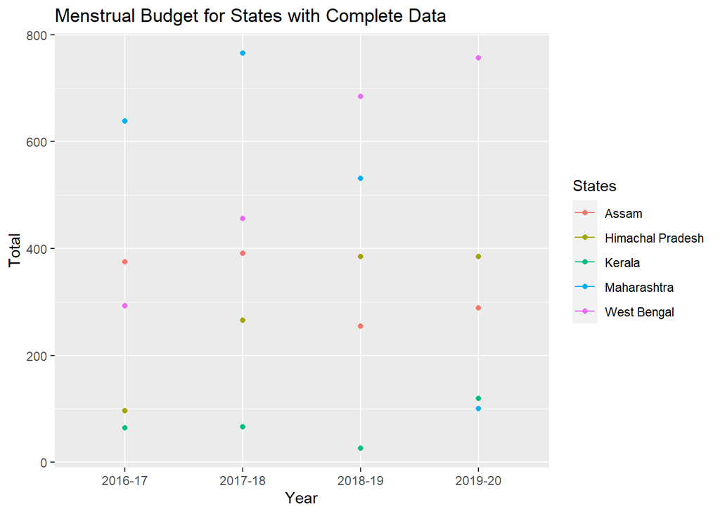

*The above plot visualizes the budget for each state (with no missing values in the the data set) from 2016-2020.*

## Specific Question Analyses

### States Spending vs. Menstrual Related Pregnancy Complications

**How does the amount of each state’s budget for a particular year impact the percentage amount of menstrual related complications?**

- Introduction:
  - For this question, our group wanted to investigate the different budget amounts spent by each state in the 2016-17 time frame to see if they had any correlation to the number of menstrual related pregnancy complications. We wanted to see if particular states were investing more efforts monetarily towards menstrual health, if that meant there would be less occurrences of menstrual related pregnancy complications.
- Data Wrangling:
  - Firstly, to begin our data wrangling, we had to manipulate our pregnancy complications data frame to filter out for the totals of each specific complication from each state. We then created a new data set by joining the pregnancy totals data frame with our menstrual budget data frame, joining by states and filtered by state, budget, and the total menstrual budget complications.

| State | budget | mens_comp | preg_comp |
| --- | --- | --- | --- |
| Andhra Pradesh | 202.53 | 12.4 | 34.9 |
| Haryana | 538.23 | 6.5 | 37.5 |
| Himachal Pradesh | 96.00 | 7.8 | 39.8 |
| Kerala | 64.00 | 8.8 | 45.1 |
| Maharashtra | 638.40 | 9.2 | 30.9 |
| Manipur | 0.00 | 17.6 | 40.5 |
| Mizoram | 6.05 | 11.4 | 35.8 |
| Punjab | 136.80 | 14.1 | 32.6 |
| Telangana | 169.30 | 8.4 | 37.9 |
| Tripura | 41.18 | 8.4 | 51.5 |
| West Bengal | 292.80 | 19.5 | 46.0 |

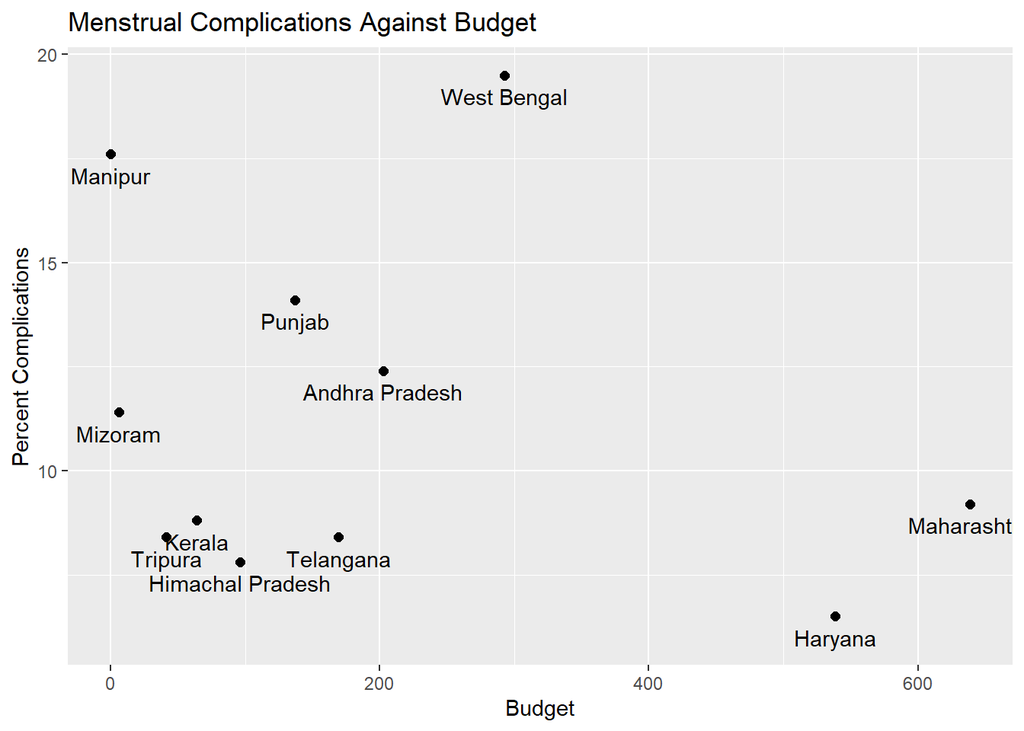

- Results Evaluation:
  - The data in the graph is inconclusive in answering the analysis question.
  - Given our data sets, the joined data is not an accurate representation of the population of India. There are only 11 out of the 23 states represented. This may be to the lack of responses of budget data and pregnancy complication data from particular states.
  - Additionally, there are some obvious outliers in the data seen in the graph further down the x-axis. West Bengal and Maharashtra are obvious outliers because they don’t seem to be following the trend of decreasing number of complications with increasing budget.
  - However, currently if a line of best fit were to be drawn, there would be a loose correlation between the budget spent in 2016-17 and the number of menstrual related pregnancy complications present. It is yet to be determines if these are truly correlated or if there may be a hidden variable such as birth rate or access to healthcare.
  - In the end, we can not confidently answer our analysis question without more sufficient data from a wider sample of India’s population.

### States Spending vs. Total Percentage Pregnancy Complications

**How does the does each states’ budget correlate to the percentage of overall pregnancy complications?**

- Introduction:
  - For this question, our group wanted to investigate the different budget amounts spent by each state in the 2016-17 time frame to see if they had any correlation to the total percentage amount of pregnancy complications. We used the same percentage of women with pregnancy complications data set as the last analysis question. Similar to the last analysis question, we wanted to be able to compare if menstrual related pregnancy complications play a large role in the total percentage amount of pregnancy complications.
- Data Wrangling:
  - Firstly, to begin our data wrangling, we had to manipulate our pregnancy complications data frame to filter out for the totals of each specific complication from each state. We then created a new data set by joining the pregnancy totals data frame with our menstrual budget data frame, joining by states and filtered by state, budget, and the total percentage of pregnancy complciations

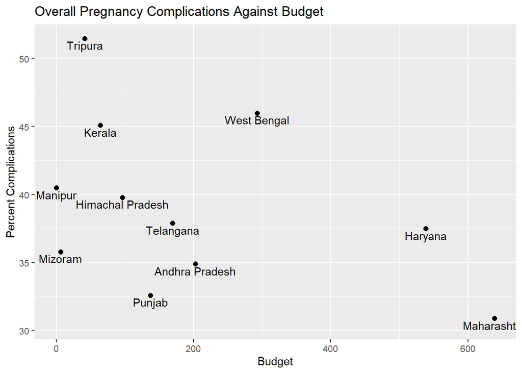

### Distribution of State Menstrual Health Budget in 2019-2020

**What does the distribution of the menstrual health budget look like in 2019-20 across different states in the data set?**

- Introduction:
  - Our group created this analysis question to investigate the most recent menstrual budget data and how the quantities of spending are broken down by state. We wanted to be able to get an idea of the spending by state and the comparison between budgets for the most recent time frame. We figured that the best way to visualize this is using a pie chart in order to understand the size of the budget distribution with different slices of the pie.
- Data Wrangling:
  - For our data wrangling, we first filtered menstrual health budget data frame for the year 2019-20 where the budget is greater than 0. We then created a pie chart that would easily visualize the distribution of each state’s budget from the year in relation to each other.

| state_no | States | 2016-17 | 2017-18 | 2018-19 | 2019-20 |
| --- | --- | --- | --- | --- | --- |
| 2 | Assam | 374.47 | 390.70 | 254.43 | 288.62 |
| 3 | Bihar | 125.16 | 183.45 | 0.00 | 957.60 |
| 5 | Delhi | 0.00 | 0.00 | 82.08 | 72.96 |
| 8 | Himachal Pradesh | 96.00 | 266.00 | 385.17 | 385.17 |
| 10 | Kerala | 64.00 | 66.50 | 26.60 | 119.70 |
| 12 | Maharashtra | 638.40 | 766.08 | 531.45 | 100.00 |
| 13 | Manipur | 0.00 | 0.00 | 0.00 | 116.20 |
| 15 | MP | 0.00 | 0.00 | 0.00 | 107.25 |
| 16 | Odisha | 682.73 | 502.95 | 0.00 | 382.23 |
| 17 | Puducherry | 0.00 | 0.00 | 0.00 | 36.00 |
| 19 | Rajasthan | 0.00 | 0.00 | 0.00 | 3000.00 |
| 21 | Tripura | 41.18 | 0.00 | 0.00 | 5.16 |
| 22 | Uttarakhand | 95.84 | 0.00 | 105.64 | 134.06 |
| 23 | West Bengal | 292.80 | 456.26 | 684.13 | 756.65 |

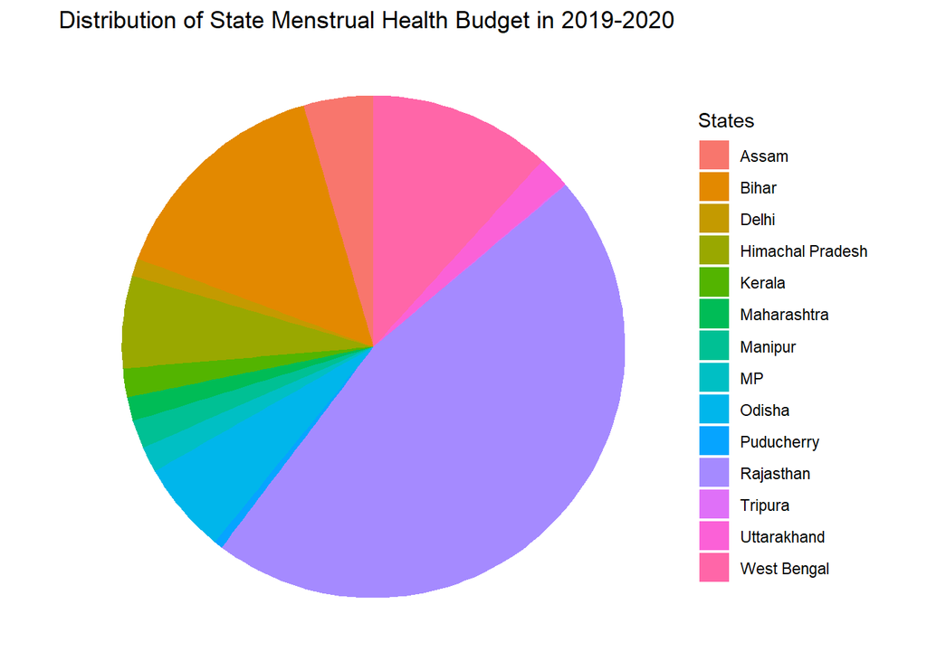

- Results Evaluation:
  - The data in the pie chart is inconclusive in answering our data analysis question.
  - The most prominent outlier is the state of Rajasthan because they provided the largest spending budget, but it was also the state’s only entry in the data frame.
  - Another stipulation is that the data set is the graph is not accurately representative of the entire population of India. There is ambiguity as to whether some regions listed in the data set are states versus cities. Additionally, there is the exclusion of some states.
  - In the end, we can not confidently answer our analysis question without more sufficient data from a wider sample of India’s population.

### Distribution of Pregnancy Complications by State

**What is the distribution of pregnancy complications by state?**

- Introduction:
  - As a group, wanted to be able to pinpoint the most common types of pregnancy complication by state. Therefore, we decided to visualize the percentages of complications across the data time period as a faceted bar graph. The distribution of pregnancy complications by state is easily comparable in this manner and summarizes the most common type of complication in an easy-to-read fashion.
- Data Wrangling:
  - For our data wrangling, we decided to group by state, use a summarize function to aggregate all of the values for each type of complication and created a new column to include all of these values. Finally, we used the pivot_longer() function to include percentages for each complication.

| States | Complications | value |
| --- | --- | --- |
| Andaman and Nicobar Islands | any_delivery_comp | 39.1 |
| Andaman and Nicobar Islands | any_post_delivery_comp | 21.1 |
| Andaman and Nicobar Islands | preg_comp | 46.2 |
| Andaman and Nicobar Islands | vag_discharge_comp | 6.5 |
| Andaman and Nicobar Islands | menstrual_related_comp | 11.7 |
| Andhra Pradesh | any_delivery_comp | 19.9 |

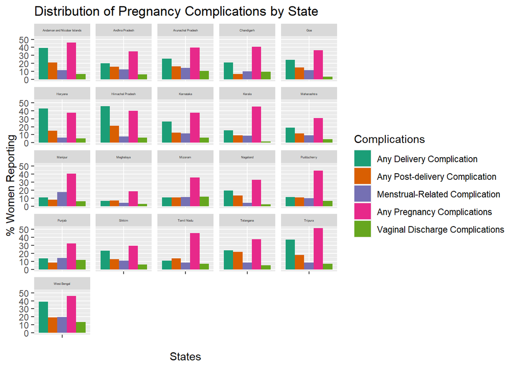